# Part II - Exploratory & Explanatory Data Analysis of Prosper Loan

## BY Yahaya Musa Kayode

## Introduction

> Prosper was founded in 2005 as the first peer-to-peer lending marketplace in the United States. Since then, Prosper has facilitated more than $23 billion in loans to more than 1,400,000 people, [source](https://www.prosper.com/about).  
> The dataset used in this project contained 113,937 loan reocords with 81 variables on each loan from the 4th quarter 2005 to the 1st quarter 2014. These variables includes loan amount, borrower rate, current loan status, borrower income borrower employment status, borrower annual percentage rate among others. Complete details about the data dictionary can be found [here](https://docs.google.com/spreadsheets/d/1gDyi_L4UvIrLTEC6Wri5nbaMmkGmLQBk-Yx3z0XDEtI/edit#gid=0).

## Investigation Overview

> The primary goal of this project is to investigate some of the factors that could influence changes in Borrower's Annual Percentage Rate, relationships between Borrower's Annual Percentage Rate and other features, among others..

## Dataset Overview

> The dataset used in this project contained 113,937 loan records with 81 variables on each loan record from 4th quarter 2005 to 1st quarter 2014. Complete details about the dataset and data dictionary can be found [here](https://docs.google.com/spreadsheets/d/1gDyi_L4UvIrLTEC6Wri5nbaMmkGmLQBk-Yx3z0XDEtI/edit#gid=0).

## Distribution Borrower's Annual Percentage Rate

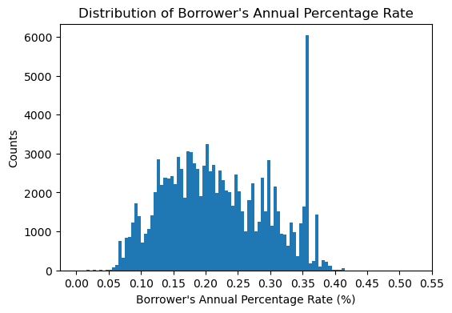

## Relationship Between Borrower's Annual Percentage Rate and Lender Yield

> A strong postive correlation can be oberved between the Borrower's Annual Percentage Rate and Lender Yield, because as the Borrower's Annual Percentage Rate increases, the Lender Yield also increase.

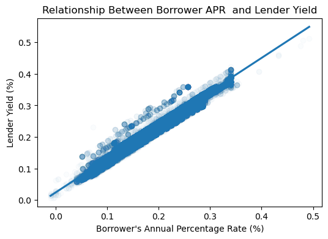

## Relationship Between Borrower's Annual Percentage Rate and Prosper Score

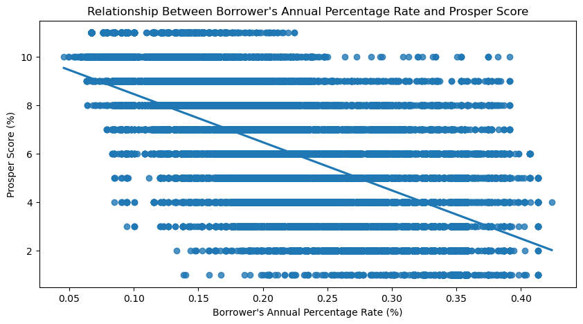